# Atividade 02 - Mineração de Dados

Marcel Dantas de Quintela

07 de março de 2021

# Instruções

1. De acordo com sua preferência, selecione um texto (ou mais de um, caso deseje). Pode ser uma notícia, um artigo de jornal (revista), um discurso, um script de filme, um roteiro de história em quadrinhos, um capítulo de livro ou algo do gênero. Escreva o texto ou informe sua fonte.
2. Importe o texto para o R e limpe-o: retire pontuação, símbolos, números (se não forem relevantes) e stopwords. Em seguida, faça um gráfico de barras com as 10 palavras mais frequentes e uma nuvem de palavras. Pode-se utilizar os pacotes wordcloud e/ou wordcloud2.
3. (Não obrigatório) Faça quaisquer outras análises do texto que julgar interessante ou relevante.

*A atividade deve ser feita no `R Markdown` e entregue em HTML ou PDF com os códigos explicitados e as análises comentadas. Os gráficos devem ser explicativos, com nomes corretos nos eixos, por exemplo.*

# Execução

## Intalando Pacotes

```r
library(knitr)
     library(kableExtra)
     library(dplyr)
     library(rmdformats)
     library(tm)
     library(pdftools)
     library(ggplot2)
     library(stringi)
     library(wordcloud)

     knitr::opts_chunk$set(
         echo = TRUE,
         message = FALSE,
         warning = FALSE)
```

## Coletando Dados

[figure not shown]

[<<Link para o livro>>](http://objdigital.bn.br/Acervo_Digital/Livros_eletronicos/cortico.pdf)

```r
x<-pdf_text(pdf ="http://objdigital.bn.br/Acervo_Digital/Livros_eletronicos/cortico.pdf")
     #pdf_text uado para extrair texto do pdf
```

## Tratamento

Criando um objeto do tipo `tm::Corpus` por meio da função `tm::VectorSource` que interpreta cada elemento do vetor x como um documento. Neste caso cada página do livro em formato pdf é um elemento incorporado ao objeto.

```r
cortico <- Corpus(VectorSource(x))
```

As funções abaixo, ajudarão no processamento do texto, padronizando letras minusculas; removendo números, pontuação, acentos e caracteres especiais; e transformando palavras e termos.

O mecanismo que processará a maioria dos ajustes no texto virá da função `tm_map` do pacote `tm`.

```r
cortico <- tm_map(cortico, tolower)           # todas minusculas
     cortico <- tm_map(cortico, removePunctuation) # remove pontuação
     cortico <- tm_map(cortico, removeNumbers)     # remove numeros
```

Para remoão dos acentos foi necessário utilizar a função `stri::stri_trans_general`. Outra função que pode fazer este trabalho é a `iconv`, no entanto não foi obtido o resultado esperado.

```r
#Função para remover todos os Acentos
     Tirar<-function(x) stri_trans_general(x,"Latin-ASCII")

     for (i in seq(cortico)){
       cortico[[i]]$content<-Tirar(cortico[[i]]$content)
     }

     #inspect(cortico[1])
```

Segundo o («Wikipedia::Stopwords» 2015), *stopword* é uma palavra que é removida antes ou após o processamento de um texto em linguagem natural. São as palavras mais comuns de uma língua, como conjunções, preposições e artigos utilizadas como elemento de ligação entre orações ou seus termos.

Algumas discursões são travadas quanto a remoção ou não das stopwords, as quais não serão abordadas neste trabalho, o qual removerá as stopwords.

Após a remoção das stopwords é conveniente remover os espaços vazios duplos.

```r
myStopwords <- c(stopwords('portuguese'),readLines("Stopwords_Portugues.txt"))

     cortico <- tm_map(cortico, removeWords, myStopwords)  # remove stopwords
     cortico <- tm_map(cortico, stripWhitespace)           # remove espaçoes duplos

     #inspect(cortico[1])
```

Ajuste de termos compostos comuns ao texto como os nomes dos personagens principais :

```r
# Ajuste por conta da palavra estrutura
     for (i in seq(cortico)){
       cortico[[i]]<- gsub("joao romao","joao.romao",cortico[[i]])
       cortico[[i]]<- gsub("rita baiana","rita.baiana",cortico[[i]])
       cortico[[i]]<- gsub("cabeca de gato","cabeca.de.gato",cortico[[i]])
       cortico[[i]]<- gsub("homens","homem",cortico[[i]])
       cortico[[i]]<- gsub("mulheres","mulher",cortico[[i]])
     }
```

## Análise

Após o pré-processamento do texto, precedemos com algumas análises.

A função `tm::DocumentTermMatrix` cria uma matriz dos termos dos documentos presentes no corpus, neste caso, de cada página do livro.

```r
data.Dtm = DocumentTermMatrix(cortico,
                                   control=list(wordLengths=c(5,46),
                                                bounds=list(global = c(6,Inf))))
```

### Explorando

```r
mat = as.matrix(data.Dtm)
     #rm(Freq)
     freq = sort(colSums(mat), decreasing=TRUE)
     Freq = data.frame(word=names(freq), freq=freq)
     rm(freq);rownames(Freq)<-c()

     kable_classic(kable(Freq[Freq[,2]>50,],
                         caption = "Lista dos Termos de 'O Cortiço' com mais de 50 ocorrências"),
                   full_width = T, html_font = "Cambria")
```

Lista dos Termos de ‘O Cortiço’ com mais de 50 ocorrências

| word | freq |
| --- | --- |
| homem | 186 |
| mulher | 168 |
| entao | 134 |
| joao.romao | 131 |
| jeronimo | 127 |
| estalagem | 112 |
| miranda | 102 |
| porta | 101 |
| filha | 96 |
| cortico | 95 |
| noite | 95 |
| piedade | 94 |
| tempo | 90 |
| olhos | 90 |
| dentro | 88 |
| tambem | 88 |
| gente | 81 |
| ninguem | 81 |
| cabeca | 80 |
| corpo | 76 |
| assim | 75 |
| diabo | 75 |
| horas | 73 |
| vendeiro | 71 |
| mulata | 71 |
| roupa | 69 |
| marido | 69 |
| defronte | 68 |
| firmo | 68 |
| venda | 67 |
| parecia | 61 |
| afinal | 59 |
| dinheiro | 59 |
| pombinha | 59 |
| parte | 58 |
| vezes | 57 |
| servico | 56 |
| tanto | 55 |
| melhor | 55 |
| instante | 53 |
| tarde | 51 |

## Gráfico de Frequência

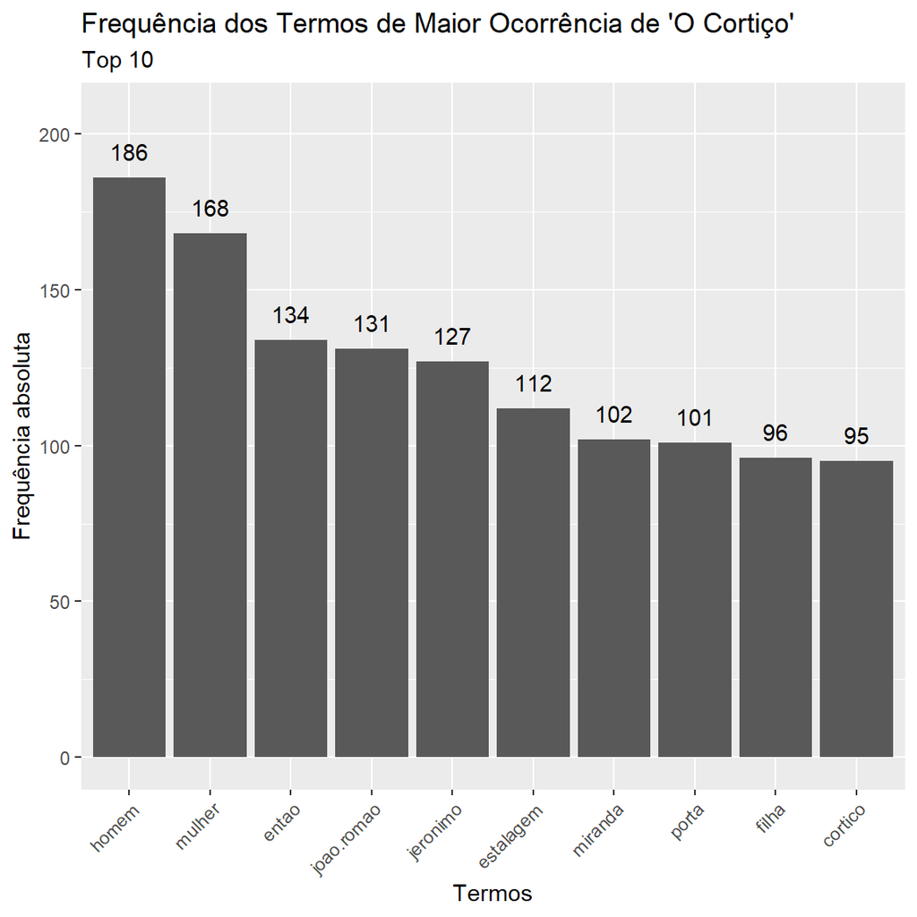

```r
#Gráfico de frequencias
     p <- ggplot(Freq[1:10,],aes(reorder(word,-freq),freq))+
                 geom_col() +
                 scale_y_continuous(limits = c(0, max(Freq[,2])+20))+
                 geom_text(aes(label = freq), vjust = -1) +
                 ggtitle("Frequência dos Termos de Maior Ocorrência de 'O Cortiço' ")+
                 geom_bar(stat="identity")+
                 labs(x="Termos",y="Frequência absoluta", subtitle = "Top 10")+
                 theme(axis.text.x=element_text(angle=45,hjust=1))
     plot(p)
```

## Nuvem de Palavras

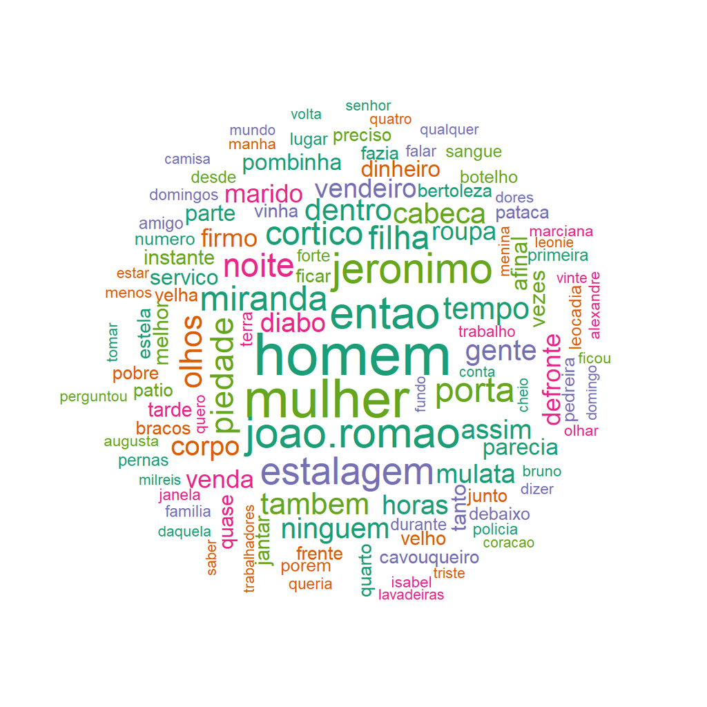

```r
wordcloud(words=Freq$word,
               freq=Freq$freq,
               scale=c(3,0.3),
               min.freq=30,
               max.words=1000,
               random.order=F,
               random.color=1,
               rot.per=.2,
               use.r.layout=T,
               colors=brewer.pal(5, "Dark2"))
```

```r
# Funciona no Rstudio mas na compilação não aparece no html :[
     # wordcloud2(Freq,
     #           size =0.5,
     #           minSize = 10,
     #           color="random-light")
```

## Análises Adcionais

Em *Text Mining*, geralmente se obtém matrizes muito grandes, com muitas células zero. Pode ser inteligente não armazenar todas as células uma a uma na memória, mas apenas armazenar as poucas entradas diferentes de zero + suas posições para economizar memória.

Assim devemos remover os termos que não aparecem com muita frequência. Uma forma possível é remover qualquer elemento que não apareça em pelo menos x% das entradas, neste caso 30% (`sparse=0.70`).

```r
# print("---------------Original DTM -----------------")
     # print("-----90% da matrix com 0 'zeros' ------------")
     inspect(data.Dtm)
```

```
## <<DocumentTermMatrix (documents: 130, terms: 973)>>
     ## Non-/sparse entries: 13080/113410
     ## Sparsity           : 90%
     ## Maximal term length: 14
     ## Weighting          : term frequency (tf)
     ## Sample             :
     ##      Terms
     ## Docs  cortico entao estalagem filha homem jeronimo joao.romao miranda mulher
     ##   100       2     2         3     2     3        3          1       0      1
     ##   111       0     1         1     5     3        5          0       0      3
     ##   114       1     0         2     0     1        1          2       1      2
     ##   2         0     2         0     0     2        0          4       0      1
     ##   28        2     0         2     0     2        0          1       1      1
     ##   33        0     1         1     1     0        1          0       1      2
     ##   45        1     1         2     0     1        0          0       0      5
     ##   63        0     0         2     0     2        2          2       1      1
     ##   75        1     0         1     4     1        1          0       0      2
     ##   99        2     0         1     0     1        3          1       0      0
     ##      Terms
     ## Docs  porta
     ##   100     2
     ##   111     0
     ##   114     3
     ##   2       1
     ##   28      1
     ##   33      2
     ##   45      1
     ##   63      0
     ##   75      0
     ##   99      0
```

```r
# print("--------------Removed sparce DTM ------------")
     # print("-----56% da matrix com 0 'zeros' ------------")
     removeSparseTerms(data.Dtm, sparse = 0.7)
```

```
## <<DocumentTermMatrix (documents: 130, terms: 37)>>
     ## Non-/sparse entries: 2094/2716
     ## Sparsity           : 56%
     ## Maximal term length: 10
     ## Weighting          : term frequency (tf)
```

```r
mat2<-as.matrix(removeSparseTerms(data.Dtm, sparse = 0.7))
```

### Dendograma

Montando uma representação de cluster, meramente ilustraiva.

Esta representação pode auxiliar em uma análise de possíveis núcleos/temática dentro no contexto do obra estudada.

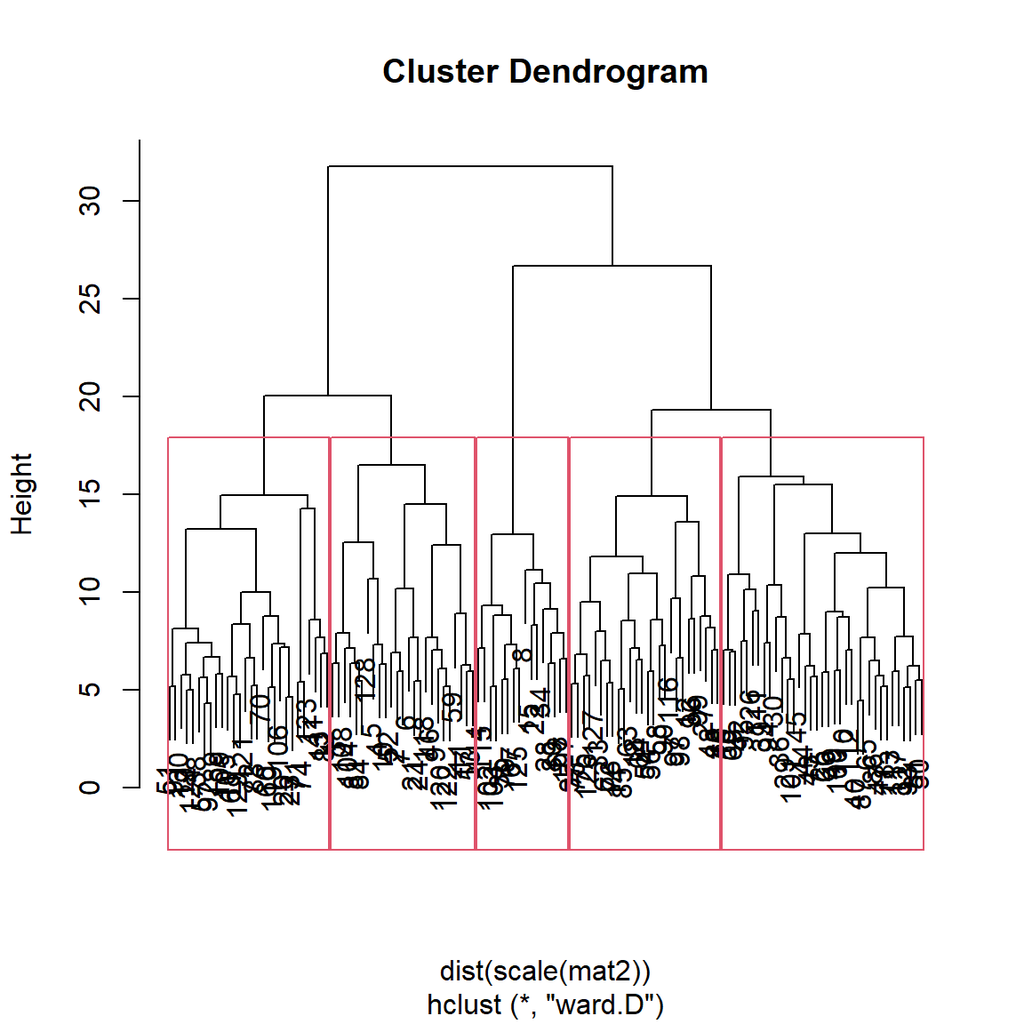

```r
fclust<-hclust(dist(scale(mat2)),method="ward.D")
     plot(fclust)
     rect.hclust(fclust,h=17)
```

### Mapa Relacional

Mais uma representação, meramente ilustrativa, a partir das correlações entre os termos.

Foi definido uma correlação de `0.10`entre os termos com frequência igual ou superior a `80`.

Este mapa pode ser uma ferramenta analítica dos relacionamentos entre os personagens, por exmplo.

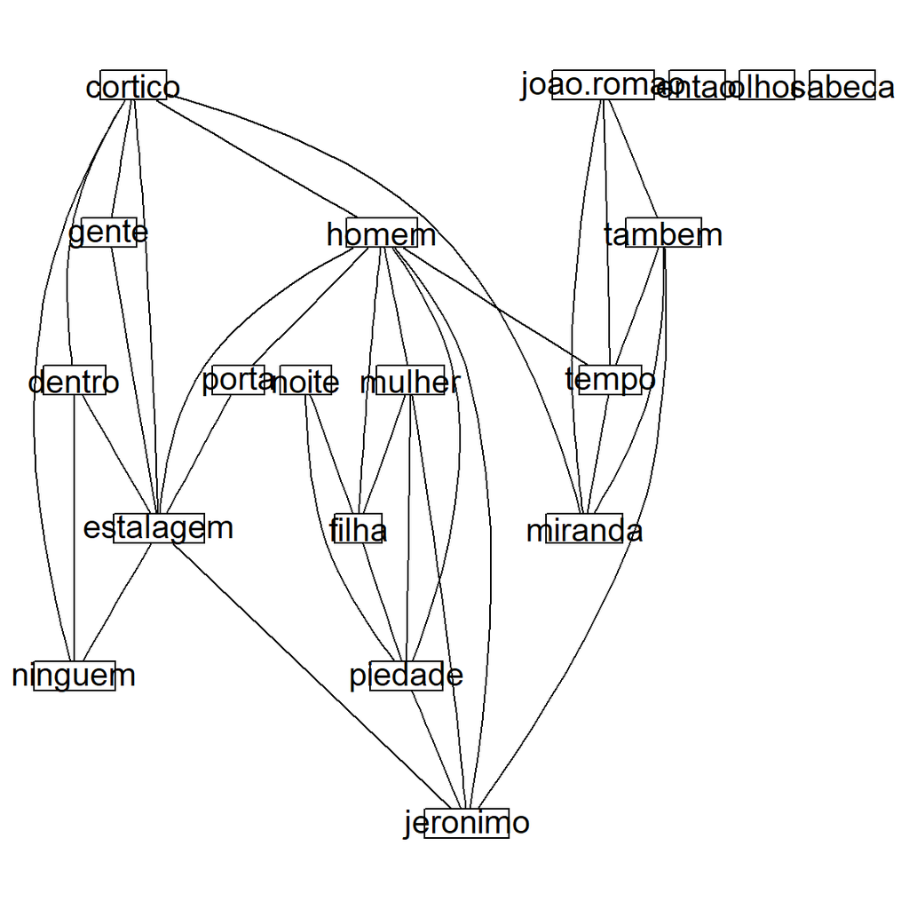

```r
a<-findFreqTerms(data.Dtm, lowfreq=80)

     plot(data.Dtm,
          terms=a,corThreshold=0.1,
          attrs=list(node=list(shape="rectangle",fixedsize=F,fontsize="25"),
                     edge=list(color="black")))
```

«Wikipedia::Stopwords». 2015. Em *Wikipédia: a enciclopédia livre*. Wikimedia. https://pt.wikipedia.org/wiki/Palavra_vazia.